# Compartment Syndrome

May 24, 2020

## Overview of Compartment Syndrome

## What is Compartment Syndrome?

[video not shown]

## Why does Compartment Syndrome occur?

[video not shown]

## How is Compartment Syndrome treated?

[video not shown]

## Review of Compartment Syndrome & Fasciotomy

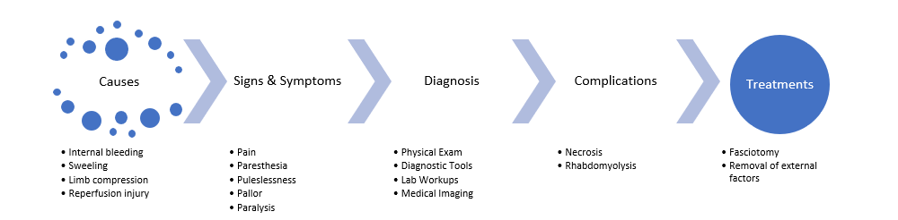

In this study, we will use **Fasciotomy** as the indicator for **Compartment Syndrome**.

- We did this for the following reasons:
  - Compartment Syndrome is a diagnosis that is subject to human error
    - The PTOS results are sparse in terms of date, time, and accuracy of diagnosis
  - Fasciotomy is a procedure that takes place because of Compartment Syndrome
    - This is a surgical procedure and it is well documented in the PTOS data

## Overview of Forearm Factures

## Four Types of Forearm Fracture Treatments

1. **Open Reduction with Internal Fixation**
   - Most common and preferred method for forearm fracture treatment
2. **Closed Reduction without Internal Fixation**
   - Involves manually setting the bone back into place and use of hard cast for stability
3. **Closed Reduction with Internal Fixation**
   - Not a surgical procedure, minor incision in forearm using pins for stability
4. **Open Reduction without Internal Fixation**
   - Surgical procedure, only performed if there is no need for internal fixator

## Review of Open Reduction Forearm Fractures

[video not shown]

## Review of Closed Reduction Forearm Fractures

[video not shown]

## Review of the Four Forearm Fracture Treatments

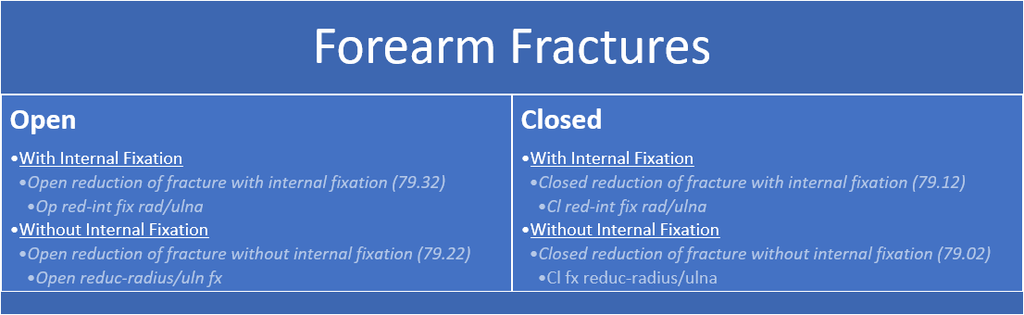

- These **are** surgical procedures
- More traumatic fractures requiring invasive techniques
- Use of plates, screws, and external cast to secure fracture site
- Patients are **sedated** using anesthesia
- These are **not** surgical procedures
- Technique performed by **manipulation** for less traumatic fractures
- Use of pins and cast to hold bones in place for healing
- Painful technique for patient and performed with or without general anesthetic

## Pennsylvania Trauma Outcome System

## What is Pennsylvania Trauma Outcome System?

[figure not shown]

This is the primary data source used for our analysis of Compartment Syndrome in Pediatrics Patients.

- Approximately 530k anonymized patient records and 1,400 columns of descriptive information regarding each procedure
- Medical results occurring between 2010 - 2015
- Patient demographics, diagnosis, prehospital procedures, surgical procedures, and outcomes
- Uses International Statistical Classification of Diseases and Related Health Problems (ICD) medical coding to classify causes of injury, examination results, processes, and treatments.

*Pennsylvania Trauma Outcome System will be referred to as **PTOS** going forward.*

## Objective of Compartment Syndrome Analysis

## Objective of Analysis

Identify the likelihood of *compartment syndrome* in pediatric patients who suffered from *forearm fractures* .

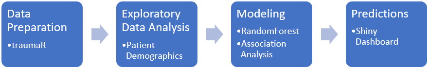

## Data Preparation

## Data Preparation: traumaR

- Developed a custom R package to translate all medical codes into human friendly terms
  - Wrote over 50 functions to automate this work and make it repeatable
- PTOS Data consists of 530k anonymized patient records and 1,400 columns
  - Columns mostly consisting of medical codes which required translation
  - Necessary to normalize the data into structured data frame
- The final results create two main data frames joined together by patient_id
  - Patient Information
  - Medical Procedures

traumaR

## Exploratory Data Analysis

## EDA: Patient

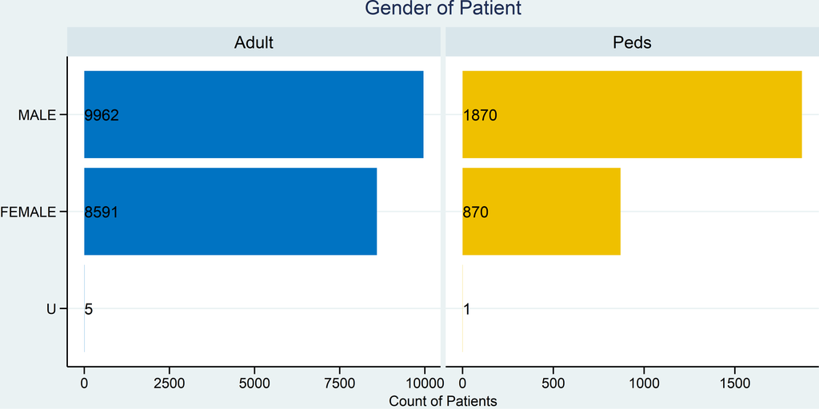

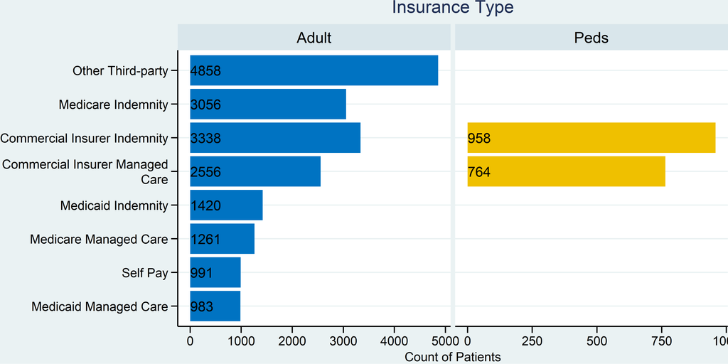

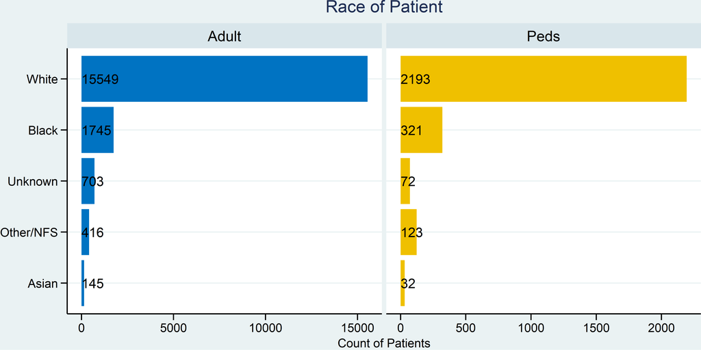

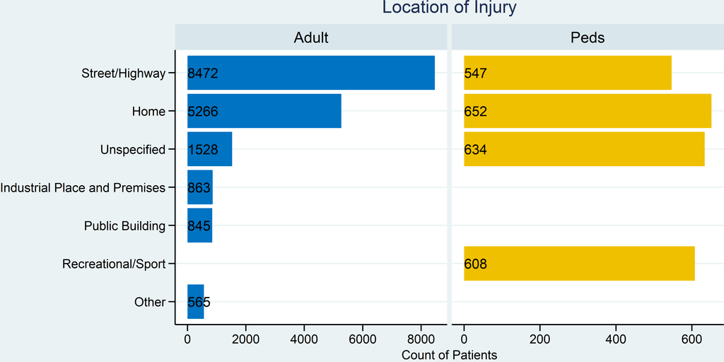

## EDA: Forearm Fractures

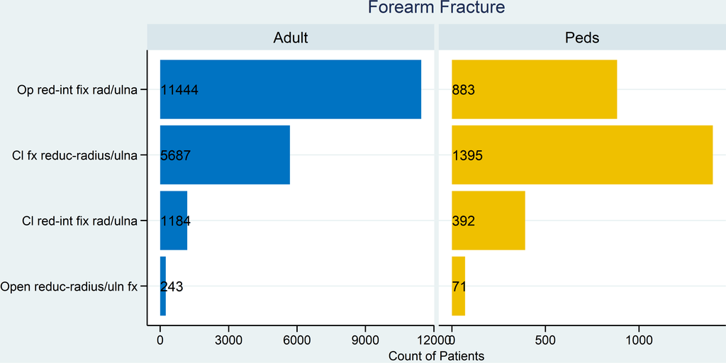

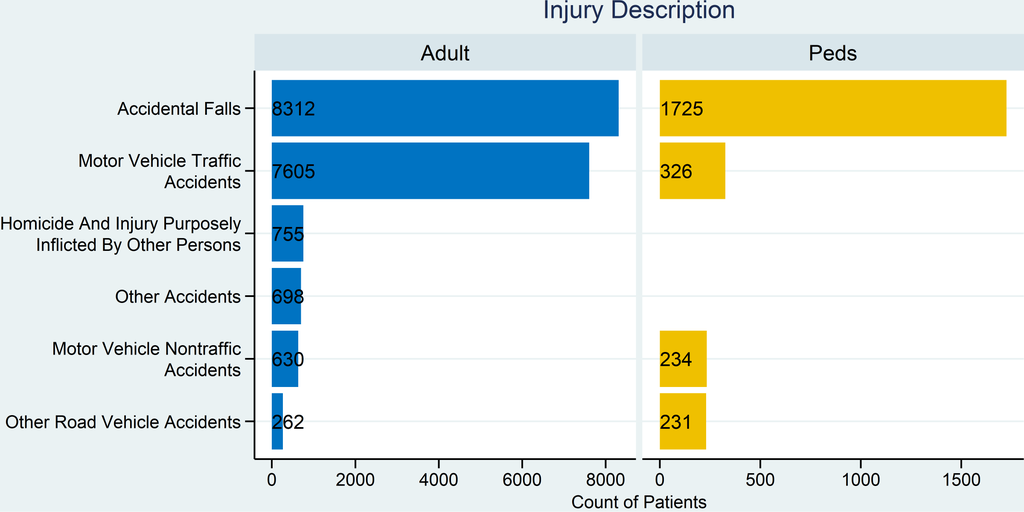

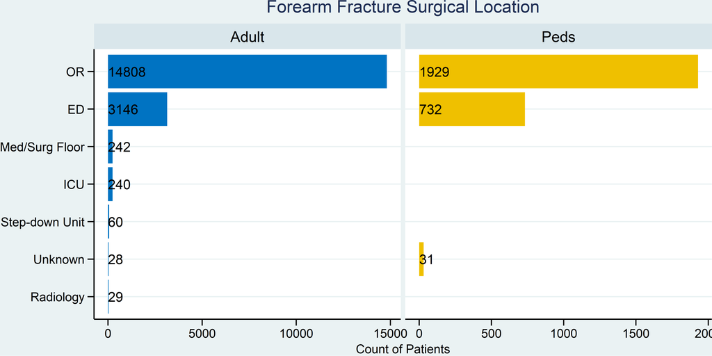

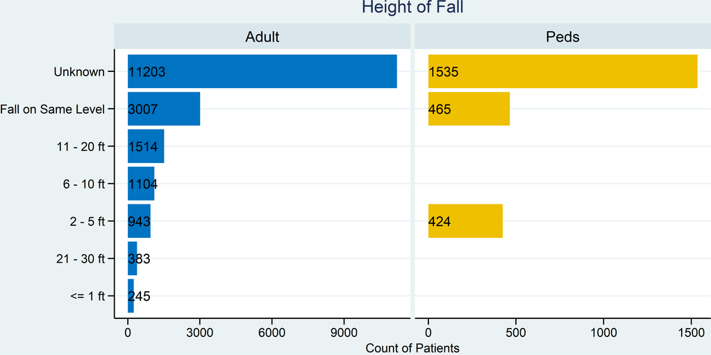

## EDA: Fasciotomy

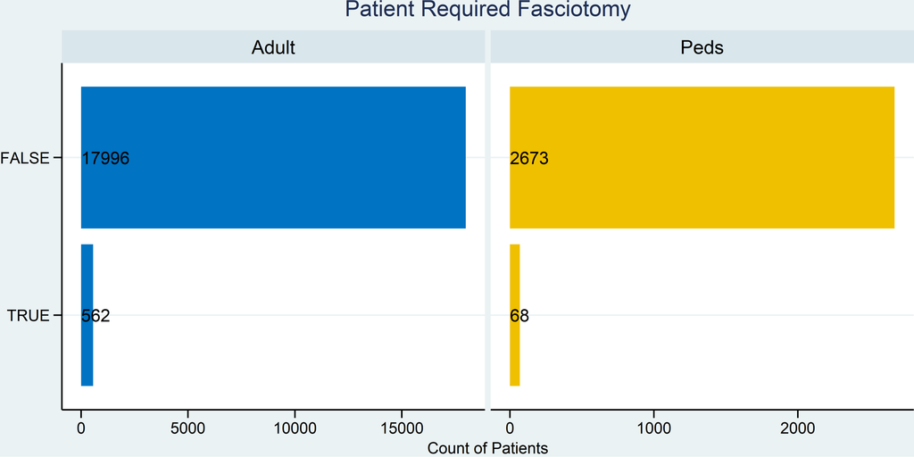

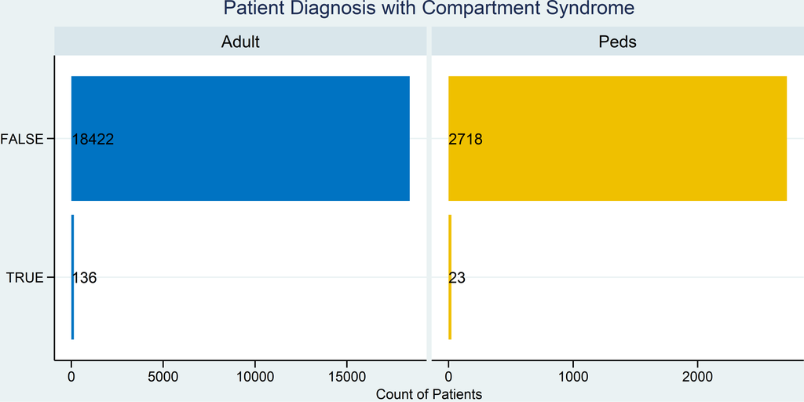

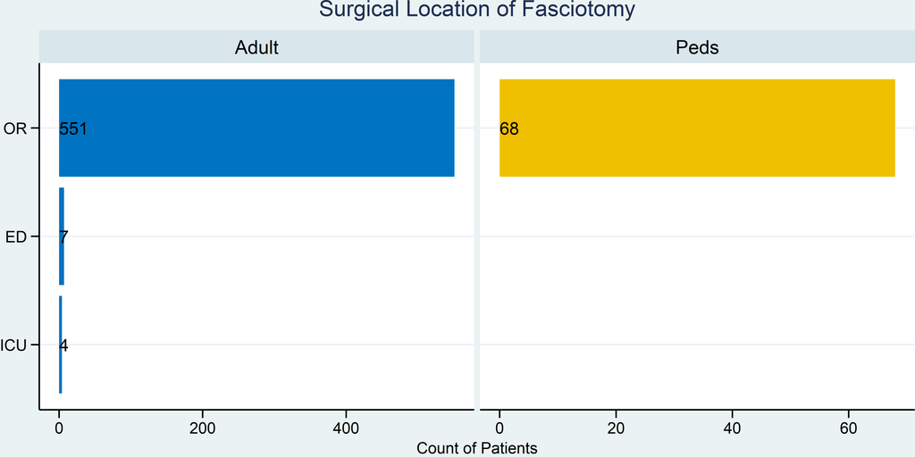

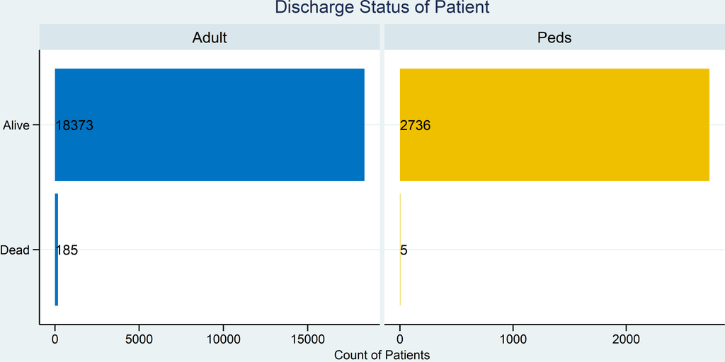

## EDA: Fasciotomy Results

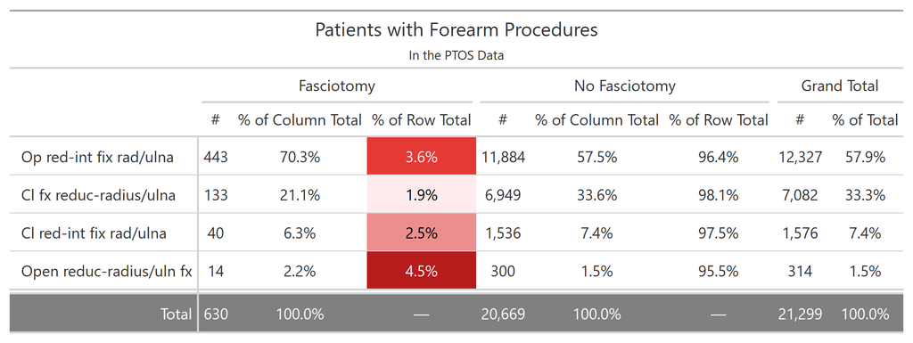

## EDA: Fasciotomy Results

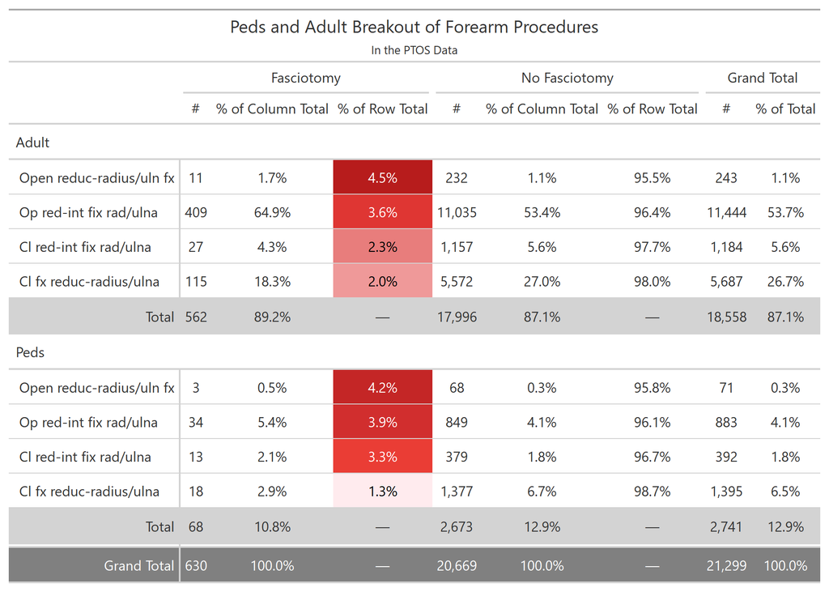

## Modeling

## Predicting Fasciotomy

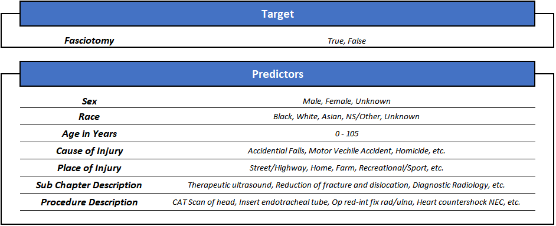

## Model Pre-Processing

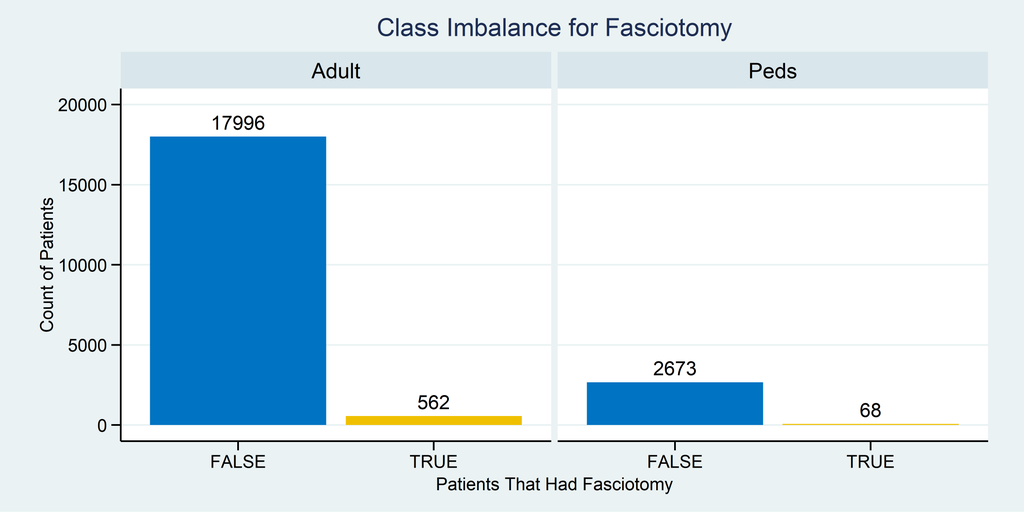

## Feature Engineering

- Step Other
  - Groups categorical information into ‘other’ category whose individual levels do not exceed preset threshold.
- Step Dummy
  - Converts character or factors into dummy variables
- Step Zero Variance
  - Removes variables that contain only a single value
    - This is a precautionary step to ensure that Step Other captured all low occurrence into ‘Other’
- Step Omit NA
  - Remove any observations with missing values
  - Some models cannot handle missing values

## Models Deployed

## Model Results: In-Sample Accuracy

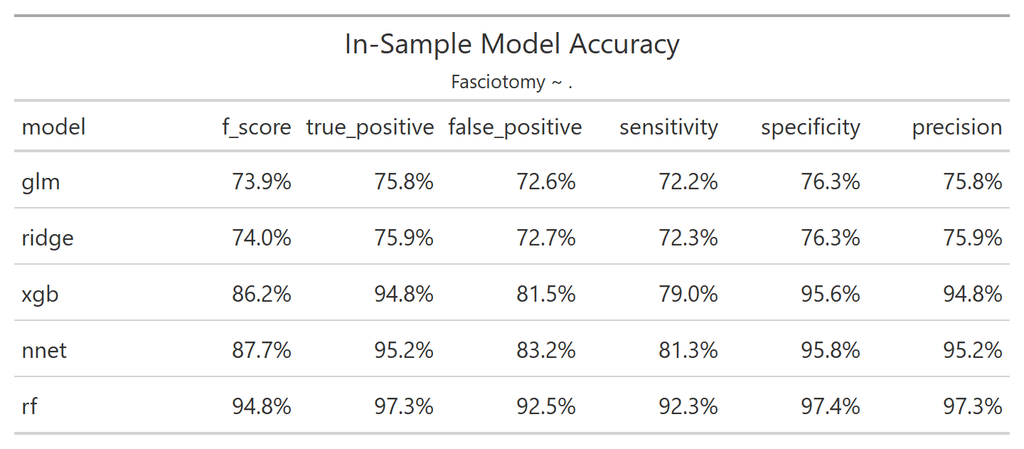

## Model Results: Out-of-Sample Accuracy

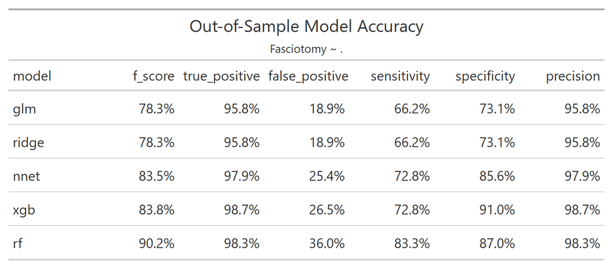

## RandomForest Variable Importance

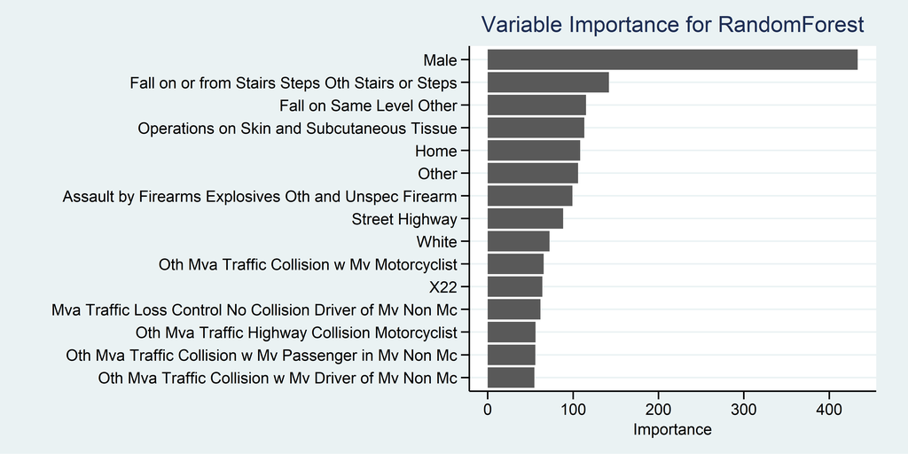

## Predictions

## Visualization

https://mjkarlsen.shinyapps.io/Compartment_Syndrome/